# Analyzing Factors Influencing Graduate Placement and Salaries Across Countries

Vyshnavi V Roll No: 2026emai20042

2026-10-26

# 1 Introduction

Graduate placement is an important milestone in a student’s career, and salary outcomes can vary depending on several factors, such as academic performance, university ranking, internship experience, skills, and specialization. This project explores these relationships using R, descriptive statistics, data visualization, and appropriate statistical methods. The aim is to understand the patterns in graduate placement and salary outcomes and identify the factors associated with them.

# 2 Objectives

1. To identify the factors associated with graduate placement outcomes.
2. To analyse the relationship between CGPA and salary.
3. To compare placement rates across different university ranking bands.
4. To examine placement rates and salary variations across countries and specializations.
5. To build and evaluate a Logistic Regression model for predicting student placement status..

# 3 Dataset Description

The dataset used for this project is the Global Student Placement & Salary Dataset, obtained from Kaggle. It contains information about students’ academic performance, skills, internship experience, placement status, and salary outcomes across five countries: Canada, Germany, India, the UK, and the USA. The dataset consists of 10,000 observations (rows) and 13 variables (columns). It includes three types of variables: integer, numeric, and categorical. Integer variables include backlogs and internship count, while numeric variables include CGPA, aptitude score, communication score, internship quality score, and annual salary. The categorical variables include college tier, country, university ranking band, specialization, industry, and placement status. This dataset is used to analyse the factors associated with graduate placement and salary differences across countries.

# 4 Data Loading and Exploration

## 4.1 Loading the Dataset

The dataset is imported into R using the `read.csv()` function.

```r
data <- read.csv(
  "D:/Mtech/S1/Data Science/Project/global_placement.csv",
  stringsAsFactors = FALSE
)

# Display the first six records
head(data)
```

```
##       cgpa backlogs college_tier country university_ranking_band
## 1 7.397371        1       Tier 2  Canada                 100-300
## 2 6.889389        0       Tier 3      UK                    300+
## 3 7.518151        0       Tier 1      UK                 100-300
## 4 8.218424        0       Tier 2      UK                 100-300
## 5 6.812677        1       Tier 2     USA                 100-300
## 6 6.812690        0       Tier 1 Germany                    300+
##   internship_count aptitude_score communication_score specialization   industry
## 1                2       53.57415            64.17706   Data Science Consulting
## 2                1       60.68775            88.34605   Data Science Consulting
## 3                2       64.56875            69.49317  Cybersecurity Healthcare
## 4                3       73.46150            78.20485          AI/ML       Tech
## 5                4       86.51812            44.68088   Data Science Consulting
## 6                1       72.87643            72.10249        Core CS Consulting
##   internship_quality_score placement_status    salary
## 1                 5.481450           Placed 104124.37
## 2                 4.625099           Placed  80586.84
## 3                 5.227939           Placed 114444.32
## 4                 5.150674           Placed 120000.00
## 5                 3.888824           Placed 120000.00
## 6                 2.917127       Not Placed      0.00
```

## 4.2 Dataset Dimensions

The output shows the number of observations and variables in the dataset.

```r
dim(data)
```

```
## [1] 10000    13
```

## 4.3 Column Names and Data Types

```r
names(data)
```

```
##  [1] "cgpa"                     "backlogs"
##  [3] "college_tier"             "country"
##  [5] "university_ranking_band"  "internship_count"
##  [7] "aptitude_score"           "communication_score"
##  [9] "specialization"           "industry"
## [11] "internship_quality_score" "placement_status"
## [13] "salary"
```

```r
str(data)
```

```
## 'data.frame':    10000 obs. of  13 variables:
##  $ cgpa                    : num  7.4 6.89 7.52 8.22 6.81 ...
##  $ backlogs                : int  1 0 0 0 1 0 1 2 0 3 ...
##  $ college_tier            : chr  "Tier 2" "Tier 3" "Tier 1" "Tier 2" ...
##  $ country                 : chr  "Canada" "UK" "UK" "UK" ...
##  $ university_ranking_band : chr  "100-300" "300+" "100-300" "100-300" ...
##  $ internship_count        : int  2 1 2 3 4 1 2 1 3 2 ...
##  $ aptitude_score          : num  53.6 60.7 64.6 73.5 86.5 ...
##  $ communication_score     : num  64.2 88.3 69.5 78.2 44.7 ...
##  $ specialization          : chr  "Data Science" "Data Science" "Cybersecurity" "AI/ML" ...
##  $ industry                : chr  "Consulting" "Consulting" "Healthcare" "Tech" ...
##  $ internship_quality_score: num  5.48 4.63 5.23 5.15 3.89 ...
##  $ placement_status        : chr  "Placed" "Placed" "Placed" "Placed" ...
##  $ salary                  : num  104124 80587 114444 120000 120000 ...
```

## 4.4 Summary

Summary statistics provide an initial understanding of the numerical and categorical variables.

```r
summary(data)
```

```
##       cgpa           backlogs        college_tier        country
##  Min.   : 4.000   Min.   :0.000   Length   :10000   Length   :10000
##  1st Qu.: 6.462   1st Qu.:0.000   N.unique :    3   N.unique :    5
##  Median : 6.998   Median :1.000   N.blank  :    0   N.blank  :    0
##  Mean   : 6.998   Mean   :1.248   Min.nchar:    6   Min.nchar:    2
##  3rd Qu.: 7.537   3rd Qu.:2.000   Max.nchar:    6   Max.nchar:    7
##  Max.   :10.000   Max.   :6.000
##  university_ranking_band internship_count aptitude_score   communication_score
##  Length   :10000         Min.   :0.000    Min.   : 30.00   Min.   : 30.00
##  N.unique :    3         1st Qu.:1.000    1st Qu.: 59.88   1st Qu.: 55.11
##  N.blank  :    0         Median :1.000    Median : 70.10   Median : 65.01
##  Min.nchar:    4         Mean   :1.499    Mean   : 69.88   Mean   : 65.16
##  Max.nchar:    7         3rd Qu.:2.000    3rd Qu.: 80.21   3rd Qu.: 75.28
##                          Max.   :5.000    Max.   :100.00   Max.   :100.00
##    specialization       industry     internship_quality_score  placement_status
##  Length   :10000   Length   :10000   Min.   : 1.000           Length   :10000
##  N.unique :    5   N.unique :    6   1st Qu.: 4.013           N.unique :    2
##  N.blank  :    0   N.blank  :    0   Median : 5.017           N.blank  :    0
##  Min.nchar:    5   Min.nchar:    4   Mean   : 5.021           Min.nchar:    6
##  Max.nchar:   13   Max.nchar:   13   3rd Qu.: 6.031           Max.nchar:   10
##                                      Max.   :10.000
##      salary
##  Min.   :     0
##  1st Qu.:     0
##  Median : 63431
##  Mean   : 55442
##  3rd Qu.:100601
##  Max.   :120000
```

# 5 Data Cleaning and Preprocessing and EDA processes applied

## 5.1 Checking for Missing Values

The is.na() function identifies missing values, and colSums() calculates the number of missing values in each column.

```r
# Count missing values in each column
colSums(is.na(data))
```

```
##                     cgpa                 backlogs             college_tier
##                        0                        0                        0
##                  country  university_ranking_band         internship_count
##                        0                        0                        0
##           aptitude_score      communication_score           specialization
##                        0                        0                        0
##                 industry internship_quality_score         placement_status
##                        0                        0                        0
##                   salary
##                        0
```

The output shows that all 13 variables contain zero missing values. Therefore, no missing-value treatment is required for the dataset at this stage.

## 5.2 Check duplicate records

```r
# Count duplicate rows
sum(duplicated(data))
```

```
## [1] 0
```

The output is 0, which indicates that there are no duplicate records in the dataset. Therefore, no duplicate rows need to be removed.

## 5.3 Check unique values and data ranges

```r
# Check unique placement statuses
unique(data$placement_status)
```

```
## [1] "Placed"     "Not Placed"
```

```r
unique(data$college_tier)
```

```
## [1] "Tier 2" "Tier 3" "Tier 1"
```

```r
unique(data$country)
```

```
## [1] "Canada"  "UK"      "USA"     "Germany" "India"
```

```r
unique(data$specialization)
```

```
## [1] "Data Science"  "Cybersecurity" "AI/ML"         "Core CS"
## [5] "Cloud"
```

```r
unique(data$industry)
```

```
## [1] "Consulting"    "Healthcare"    "Tech"          "Manufacturing"
## [5] "Other"         "Finance"
```

The unique() function identifies all distinct categories present in each categorical variable.

```r
# Check whether unplaced students have zero salary
table(data$placement_status, data$salary == 0)
```

```
##
##              FALSE TRUE
##   Not Placed     0 3847
##   Placed      6153    0
```

The table() function compares placement status with whether salary is zero. The output shows that all 3,847 Not Placed students have zero salary, while all 6,153 Placed students have a positive salary. This confirms that salary values are consistent with placement status, and zero salary should not be treated as missing data.

```r
# Convert categorical variables to factors
data$college_tier <- as.factor(data$college_tier)
data$country <- as.factor(data$country)
data$university_ranking_band <- as.factor(data$university_ranking_band)
data$specialization <- as.factor(data$specialization)
data$industry <- as.factor(data$industry)
data$placement_status <- as.factor(data$placement_status)
```

The as.factor() function converts categorical variables into factor variables in R. Here, college tier, country, university ranking band, specialization, industry, and placement status are converted into factors. This helps R recognize these variables as categories rather than ordinary text values, making them suitable for further statistical analysis and Logistic Regression modelling.

# 6 Exploratory Data Analysis (EDA)

## 6.1 Relationship between CGPA and Salary

```r
# Select only students who are placed
placed_data <- subset(
  data,
  placement_status == "Placed"
)
```

The subset() function is used to select only the students whose placement status is “Placed” from the original dataset. The selected records are stored in a new dataset called placed_data.

```r
# Check the number of rows
nrow(placed_data)
```

```
## [1] 6153
```

```r
# Display the first six records
head(placed_data)
```

```
##       cgpa backlogs college_tier country university_ranking_band
## 1 7.397371        1       Tier 2  Canada                 100-300
## 2 6.889389        0       Tier 3      UK                    300+
## 3 7.518151        0       Tier 1      UK                 100-300
## 4 8.218424        0       Tier 2      UK                 100-300
## 5 6.812677        1       Tier 2     USA                 100-300
## 7 8.263370        1       Tier 3   India                    300+
##   internship_count aptitude_score communication_score specialization
## 1                2       53.57415            64.17706   Data Science
## 2                1       60.68775            88.34605   Data Science
## 3                2       64.56875            69.49317  Cybersecurity
## 4                3       73.46150            78.20485          AI/ML
## 5                4       86.51812            44.68088   Data Science
## 7                2       61.93859            71.83707        Core CS
##        industry internship_quality_score placement_status    salary
## 1    Consulting                 5.481450           Placed 104124.37
## 2    Consulting                 4.625099           Placed  80586.84
## 3    Healthcare                 5.227939           Placed 114444.32
## 4          Tech                 5.150674           Placed 120000.00
## 5    Consulting                 3.888824           Placed 120000.00
## 7 Manufacturing                 3.366860           Placed  37961.55
```

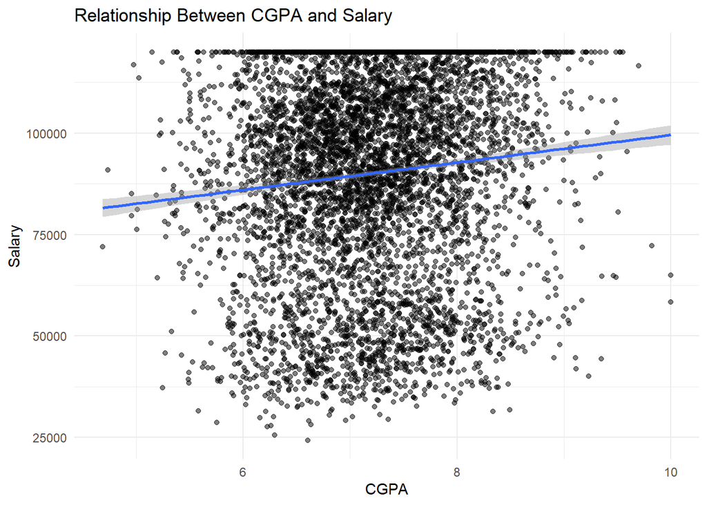

```r
library(ggplot2)
# Scatter Plot
ggplot(placed_data, aes(x = cgpa, y = salary)) +
  geom_point(alpha = 0.5) +
  geom_smooth(method = "lm", se = TRUE) +
  labs(
    title = "Relationship Between CGPA and Salary",
    x = "CGPA",
    y = "Salary"
  ) +
  theme_minimal()
```

The scatter plot shows the relationship between CGPA and salary among placed students. The fitted regression line has a positive slope, indicating a positive association between CGPA and salary. However, the points are widely scattered, suggesting considerable variation in salary among students with similar CGPA values. Therefore, CGPA alone may not fully explain salary differences.

## 6.2 Salary Outlier Detection

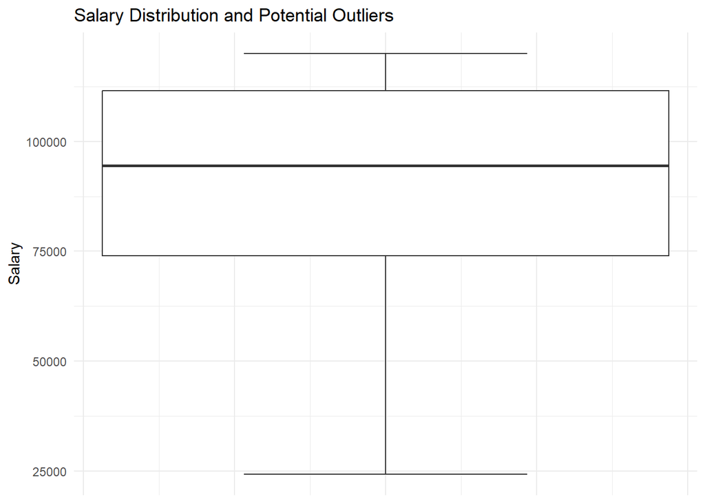

```r
ggplot(placed_data, aes(y = salary)) +
  geom_boxplot(staplewidth = 0.5) +
  labs(
    title = "Salary Distribution and Potential Outliers",
    x = NULL,
    y = "Salary"
  ) +
  theme_minimal() +
  theme(
    axis.text.x = element_blank()
  )
```

The box plot illustrates the distribution of salaries among placed students. The median salary is approximately 95,000. The middle 50% of salaries lie approximately between 74,000 and 111,000, indicating considerable variation in salary outcomes. The whiskers extend from approximately 25,000 to 120,000, and no individual outlier points are visibly displayed beyond the whiskers.

## 6.3 Placement Rate by University Ranking Band

```r
library(dplyr)
```

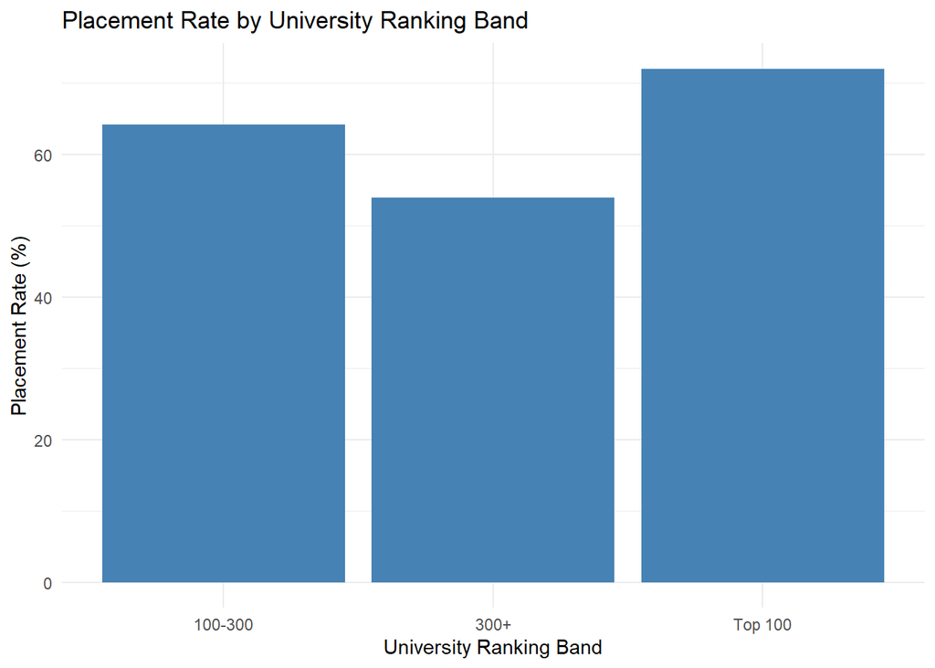

```r
# Calculate placement rate by university ranking band
ranking_placement <- data %>%
  group_by(university_ranking_band) %>%
  summarise(
    Placement_Rate = mean(placement_status == "Placed") * 100
  )

# Create bar chart
ggplot(
  ranking_placement,
  aes(x = university_ranking_band, y = Placement_Rate)
) +
  geom_bar(stat = "identity", fill = "steelblue") +
  labs(
    title = "Placement Rate by University Ranking Band",
    x = "University Ranking Band",
    y = "Placement Rate (%)"
  ) +
  theme_minimal()
```

We can observe that students from Top 100 universities have the highest placement rate, at approximately 72%. Interestingly, universities ranked between 100 and 300 have a higher placement rate than universities ranked 300 and above.This indicates that placement rates are generally higher among students from better-ranked universities in this dataset.Other student-related factors may also contribute to placement outcomes.

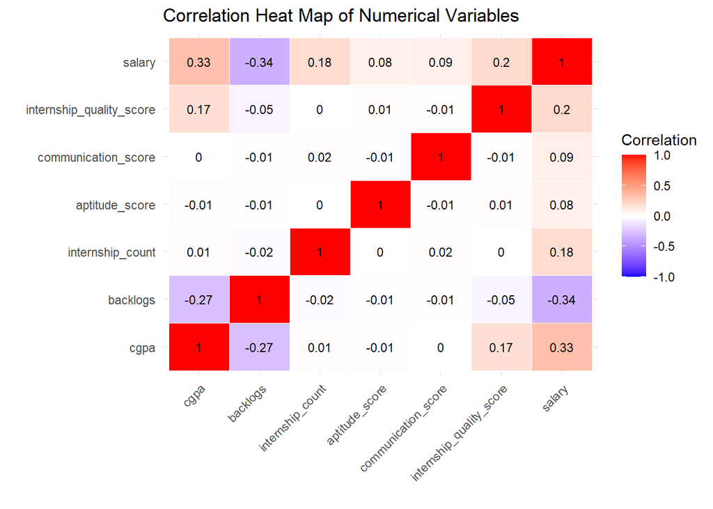

```r
## Correlation Heat Map

# Select numerical variables
numeric_data <- data[sapply(data, is.numeric)]

# Calculate the correlation matrix
cor_matrix <- cor(numeric_data, use = "complete.obs")

# Convert the matrix into a data frame
cor_df <- as.data.frame(as.table(cor_matrix))

# Create the heat map
ggplot(cor_df, aes(x = Var1, y = Var2, fill = Freq)) +
  geom_tile(color = "white") +
  geom_text(aes(label = round(Freq, 2)), size = 3) +
  scale_fill_gradient2(
    low = "blue",
    mid = "white",
    high = "red",
    midpoint = 0,
    limits = c(-1, 1)
  ) +
  labs(
    title = "Correlation Heat Map of Numerical Variables",
    x = "",
    y = "",
    fill = "Correlation"
  ) +
  theme_minimal() +
  theme(
    axis.text.x = element_text(angle = 45, hjust = 1)
  )
```

The correlation heat map shows the relationships between numerical variables. Red indicates positive correlation, while blue indicates negative correlation. We can observe that CGPA has a positive correlation with salary (0.33), while backlogs have a negative correlation (-0.34). Internship quality score (0.20) and internship count (0.18) also show positive correlations with salary. This suggests that CGPA, backlogs and internship-related factors have relatively stronger associations with salary than the other numerical variables.

## 6.4 Combined Analysis Using Facet Wrap

```r
# Calculate placement rate
placement_specialization <- data %>%
  group_by(country, specialization) %>%
  summarise(
    placement_rate =
      mean(placement_status == "Placed") * 100,
    .groups = "drop"
  )

# Calculate average salary among placed students
salary_specialization <- placed_data %>%
  group_by(country, specialization) %>%
  summarise(
    average_salary = mean(salary),
    .groups = "drop"
  )

# Combine both results
combined_analysis <- merge(
  placement_specialization,
  salary_specialization,
  by = c("country", "specialization")
)
```

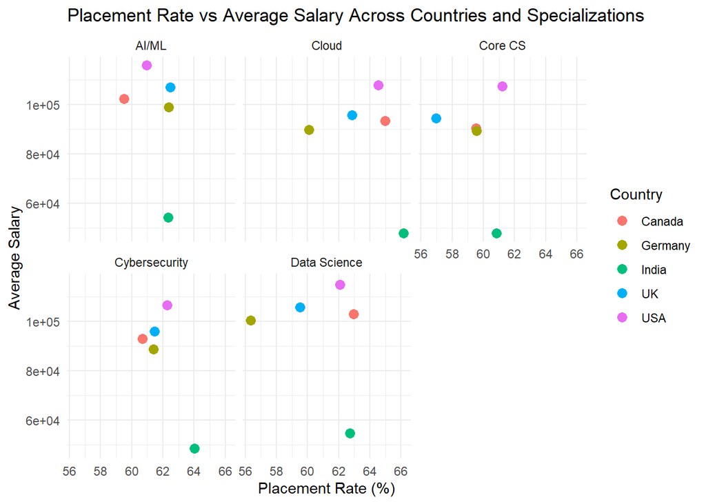

```r
ggplot(
  combined_analysis,
  aes(x = placement_rate, y = average_salary,
      color = country)
) +
  geom_point(size = 3) +
  facet_wrap(~ specialization) +
  labs(
    title = "Placement Rate vs Average Salary Across Countries and Specializations",
    x = "Placement Rate (%)",
    y = "Average Salary",
    color = "Country"
  ) +
  theme_minimal()
```

From the graph, we can observe that the USA generally has the highest average salaries across the different specializations, while India has the lowest average salaries. However, India’s placement rates are relatively high in some specializations despite its lower salary levels. The other countries also show variations in both placement rates and salaries across specializations.

This indicates that a higher placement rate does not necessarily mean a higher average salary. Both outcomes vary across countries and specializations.

```r
# Overall placement rate
overall_placement_rate <- mean(
  data$placement_status == "Placed"
) * 100

# Mean salary among placed students
mean_placed_salary <- mean(placed_data$salary)

# Median salary among placed students
median_placed_salary <- median(placed_data$salary)

# Display results clearly
cat("Overall Placement Rate:",
    round(overall_placement_rate, 2), "%\n")
```

```
## Overall Placement Rate: 61.53 %
```

```r
cat("Mean Salary Among Placed Students:",
    round(mean_placed_salary, 2), "\n")
```

```
## Mean Salary Among Placed Students: 90105.88
```

```r
cat("Median Salary Among Placed Students:",
    round(median_placed_salary, 2), "\n")
```

```
## Median Salary Among Placed Students: 94524.17
```

The overall placement rate is 61.53%, meaning 6,153 out of 10,000 students were placed. Among the placed students, the average salary is approximately 90,105.88, while the median salary is 94,524.17. These statistics provide an overall summary of placement performance and salary distribution in the dataset.

# 7 Logistic Regression

Logistic Regression is a supervised machine learning algorithm used for classification problems. In this project, it is used to predict whether a student will be placed based on academic performance, college tier, country, university ranking, internship experience, aptitude, communication skills, specialization, industry, and internship quality.

## 7.1 Preparing the Data

```r
# Create a copy of the dataset
ml_data <- data

# Exclude salary to avoid data leakage
ml_data$salary <- NULL

# Set placement status as a categorical target
ml_data$placement_status <- factor(
  ml_data$placement_status,
  levels = c("Not Placed", "Placed")
)
```

## 7.2 Splitting the Dataset

The dataset is divided into training and testing sets. The training set is used to build the model, while the testing set evaluates its performance on unseen observations.

```r
set.seed(123)

# Randomly select 80% of rows for training
train_index <- sample(
  seq_len(nrow(ml_data)),
  size = floor(0.8 * nrow(ml_data))
)

train_data <- ml_data[train_index, ]
test_data <- ml_data[-train_index, ]
```

```r
# Check dataset sizes
nrow(train_data)
```

```
## [1] 8000
```

```r
nrow(test_data)
```

```
## [1] 2000
```

## 7.3 Building the Logistic Regression Model

```r
# Train the model
placement_model <- glm(
  placement_status ~ .,
  data = train_data,
  family = binomial()
)

# Display model summary
summary(placement_model)
```

```
##
## Call:
## glm(formula = placement_status ~ ., family = binomial(), data = train_data)
##
## Coefficients:
##                                 Estimate Std. Error z value Pr(>|z|)
## (Intercept)                    -9.269997   0.383727 -24.158  < 2e-16 ***
## cgpa                            0.855683   0.040423  21.168  < 2e-16 ***
## backlogs                       -0.741827   0.027532 -26.944  < 2e-16 ***
## college_tierTier 2             -0.047885   0.067863  -0.706 0.480425
## college_tierTier 3             -0.017778   0.072596  -0.245 0.806546
## countryGermany                 -0.012618   0.087937  -0.143 0.885902
## countryIndia                    0.111480   0.089306   1.248 0.211928
## countryUK                      -0.068749   0.089165  -0.771 0.440692
## countryUSA                      0.032212   0.087898   0.366 0.714013
## university_ranking_band300+    -0.637995   0.062323 -10.237  < 2e-16 ***
## university_ranking_bandTop 100  0.592590   0.082290   7.201 5.97e-13 ***
## internship_count                0.491667   0.025720  19.116  < 2e-16 ***
## aptitude_score                  0.019059   0.001934   9.854  < 2e-16 ***
## communication_score             0.019322   0.001936   9.981  < 2e-16 ***
## specializationCloud             0.185157   0.090160   2.054 0.040009 *
## specializationCore CS           0.010790   0.088825   0.121 0.903313
## specializationCybersecurity     0.034369   0.089728   0.383 0.701695
## specializationData Science     -0.021764   0.088060  -0.247 0.804795
## industryFinance                 0.183659   0.097554   1.883 0.059749 .
## industryHealthcare              0.185588   0.097097   1.911 0.055957 .
## industryManufacturing          -0.388688   0.095159  -4.085 4.41e-05 ***
## industryOther                  -0.330082   0.096597  -3.417 0.000633 ***
## industryTech                    0.436170   0.098012   4.450 8.58e-06 ***
## internship_quality_score        0.331564   0.019884  16.675  < 2e-16 ***
## ---
## Signif. codes:  0 '***' 0.001 '**' 0.01 '*' 0.05 '.' 0.1 ' ' 1
##
## (Dispersion parameter for binomial family taken to be 1)
##
##     Null deviance: 10646.3  on 7999  degrees of freedom
## Residual deviance:  7697.9  on 7976  degrees of freedom
## AIC: 7745.9
##
## Number of Fisher Scoring iterations: 5
```

The glm() function builds a Logistic Regression model using the training data to predict placement status. The family = binomial() specifies binary classification, and summary() displays the model coefficients and statistical significance of the input variables.

## 7.4 Predicting Placement Status

```r
# Predict placement probabilities
probability <- predict(
  placement_model,
  newdata = test_data,
  type = "response"
)

# Convert probabilities into predicted classes
predicted <- ifelse(
  probability >= 0.5,
  "Placed",
  "Not Placed"
)

predicted <- factor(
  predicted,
  levels = c("Not Placed", "Placed")
)

# Create confusion matrix
confusion_matrix <- table(
  Actual = test_data$placement_status,
  Predicted = predicted
)

confusion_matrix
```

```
##             Predicted
## Actual       Not Placed Placed
##   Not Placed        460    325
##   Placed            203   1012
```

The predict() function calculates placement probabilities for the 2,000 test records. Using a threshold of 0.5, students are classified as Placed or Not Placed. The table() function then creates a confusion matrix to compare the actual placement status with the model’s predictions and identify correct and incorrect predictions.

## 7.5 Calculate accuracy

```r
accuracy <- sum(diag(confusion_matrix)) /
  sum(confusion_matrix)

cat("Model Accuracy:", round(accuracy * 100, 2), "%")
```

```
## Model Accuracy: 73.6 %
```

```r
# Calculate evaluation metrics

TP <- confusion_matrix["Placed", "Placed"]
FP <- confusion_matrix["Not Placed", "Placed"]
FN <- confusion_matrix["Placed", "Not Placed"]

precision <- TP / (TP + FP)
recall <- TP / (TP + FN)

f1_score <- 2 * (precision * recall) /
            (precision + recall)

cat("Precision:", round(precision * 100, 2), "%\n")
```

```
## Precision: 75.69 %
```

```r
cat("Recall:", round(recall * 100, 2), "%\n")
```

```
## Recall: 83.29 %
```

```r
cat("F1-Score:", round(f1_score * 100, 2), "%\n")
```

```
## F1-Score: 79.31 %
```

Precision: Of all students predicted as placed, approximately 75.69% were actually placed.

Recall: The model correctly identified approximately 83.29% of all actually placed students.

F1-score: The F1-score of approximately 79.31% represents the balance between precision and recall.

# 8 Conclusion

This mini project analysed the factors influencing graduate placement and salary outcomes across five countries using the Global Student Placement & Salary Dataset. The exploratory analysis revealed that factors such as CGPA, backlogs, internship experience, university ranking, country, and specialization are associated with placement and salary outcomes.

A Logistic Regression model was developed to predict student placement status. The model achieved 73.6% accuracy, with a precision of 75.69%, recall of 83.29%, and F1-score of 79.31%.

Overall, the project achieved its objectives by identifying important patterns in graduate placement and salary outcomes and developing a model to predict placement status. However, since the dataset is simulated, the findings should be interpreted as analytical insights rather than actual real-world placement statistics.